# lavaan Paketinin Tanıtımı

2024-09-03

Bu oturumda kullanılan paketler…

```r
library(lavaan)       ## Yem analizleri
library(dplyr)        ## veri düzenleme
library(knitr)        ## rapor ve tablo oluşturma
library(broom)        ## sonuçların düzgün elde edilmesi
library(semPlot)      ## görselleştirme
library(semptools)    ## anlamlı katsayaları görsel de gösterme
library(semoutput)    ## çıktıları tablo formatında verir.
## diğer paketlerden farklı olarak devtools::install_github("dr-JT/semoutput") komutu ile yüklenmektedir
library(GGally)       ## değişkenler arasındaki ilişkiyi inceleme
```

## lavaan Paketinin Tanıtımı

lavaan paketi (Rosseel 2012), yapısal eşitlik modellemesi (YEM), faktör analizi ve yol analizi gibi istatistiksel analizler için kullanılır. Bu paket, karmaşık modellerin kurulmasına ve analiz edilmesine olanak tanır. YEM, birden fazla bağımlı ve bağımsız ve gizil değişkenin bir arada değerlendirildiği karmaşık modellerin oluşturulmasını sağlar.

R’de lavaan paketini kurmak ve etkinleştirmek için aşağıdaki kodu kullanabilirsiniz:

```r
install.packages("lavaan")
library(lavaan)
```

İlk olarak lavaan paketi ile gerçekleştirilebilen analizlere göz atalım.

- Basit Doğrusal Regresyon

```r
# tek bağımsız değişkenli model
model <- 'y ~ x'
sonuc <- sem(model, data = data)
summary(sonuc,rsquare=TRUE,standardized =TRUE)
```

- Çoklu Regresyon

```r
# İki bağımsız değişkenli model
model <- 'y ~ x1 + x2'
sonuc <- sem(model, data=data)
summary(sonuc,rsquare=TRUE,standardized =TRUE)
```

- Faktör Analizi

```r
# Her bir faktörde üç göstergenin olduğu iki faktörlü model
model <- 'f1 =~ x1 + x2 + x3
          f2 =~ x4 + x5 + x6'
sonuc <- sem(model, data = data)
summary(sonuc,standardized =TRUE)
```

- Yol Analizi

```r
# Model tanımı
model <- 'y1 ~ x1 + x2
          y2 ~ x2 + x3 +x4
          x3 ~ x1'
summary(sonuc,standardized =TRUE)
```

🔗 [Paketin web sayfası mutlaka incelenmelidir.](https://lavaan.ugent.be/)

### Model syntaxları

Faktör analizi ve regresyon modellerinde operatör kullanımlarının farklı olduğunu dikkatinizi çekmiştir. Opertörler, anlamları ve açıklamalarıyla tablo halinde aşağıda verilmiştir

[output not shown]

# Basit Doğrusal Regresyon

Basit ve çoklu regresyon modelleri kurarak, bağımlı değişkenin bağımsız değişkenlerle olan ilişkisini incelemek mümkündür. Basit doğrusal regresyon modeli kurmak için aşağıdaki örneği inceleyebilirsiniz:

```r
# Veri seti
set.seed(41)
reg_data <- data.frame(x = rnorm(100), y = rnorm(100))
```

Regresyon analizlerinde, analiz öncesinde değişkenlerin dağılımlarını ve birbirleri ile ilişkilerini incelemek için GGally paketinin (Schloerke et al. 2024) `ggpairs()` fonksiyonu kullanılabilir.

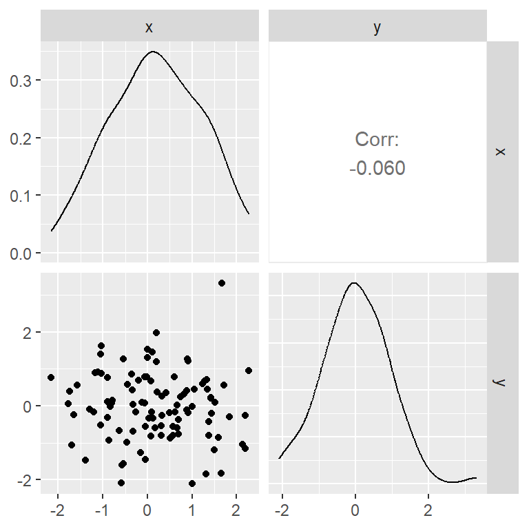

```r
library(GGally)
ggpairs(reg_data)
```

İki değişkenin de normal dağıldığı ve aralarında ilişki olmadığı *(r=-.06,p>0.05)* görülmektedir.

Basit resgresyon modeli analizi çıktısında determinasyon katsayısını elde etmek için `rsquare=TRUE` ve standarlaştırmış regresyon katsayılarının elde edilmesi için `standardized =TRUE` argümanları `summary()` fonksiyonu içinde kullanılmıştır.

```r
library(lavaan)

# Model tanımı
reg_model <- 'y ~ x'

# Modeli fit etme
reg_fit <- sem(reg_model, data = reg_data)
summary(reg_fit,rsquare=TRUE,standardized =TRUE)
```

```
## lavaan 0.6.17 ended normally after 1 iteration
##
##   Estimator                                         ML
##   Optimization method                           NLMINB
##   Number of model parameters                         2
##
##   Number of observations                           100
##
## Model Test User Model:
##
##   Test statistic                                 0.000
##   Degrees of freedom                                 0
##
## Parameter Estimates:
##
##   Standard errors                             Standard
##   Information                                 Expected
##   Information saturated (h1) model          Structured
##
## Regressions:
##                    Estimate  Std.Err  z-value  P(>|z|)   Std.lv  Std.all
##   y ~
##     x                -0.054    0.090   -0.596    0.551   -0.054   -0.060
##
## Variances:
##                    Estimate  Std.Err  z-value  P(>|z|)   Std.lv  Std.all
##    .y                 0.855    0.121    7.071    0.000    0.855    0.996
##
## R-Square:
##                    Estimate
##     y                 0.004
```

## Düzenli tablolar

broom paketindeki (Robinson, Hayes, and Couch 2023) `tidy()` fonksiyonu ile çıktı daha düzgün elde edilebilmektedir. Çıktıların tablo haline getirilmesi için ise knitr paketindeki (Xie 2024) `kable()` fonksiyonu kullanılabilir.

```r
library(dplyr)
library(knitr)
library(broom)
tidy(reg_fit)  %>% kable(digit=3)
```

| term | op | estimate | std.error | statistic | p.value | std.lv | std.all | std.nox |
| --- | --- | --- | --- | --- | --- | --- | --- | --- |
| y ~ x | ~ | -0.054 | 0.090 | -0.596 | 0.551 | -0.054 | -0.060 | -0.058 |
| y ~~ y | ~~ | 0.855 | 0.121 | 7.071 | 0.000 | 0.855 | 0.996 | 0.996 |
| x ~~ x | ~~ | 1.047 | 0.000 | NA | NA | 1.047 | 1.000 | 1.047 |

## Görselleştirme

semPlot paketindeki (Epskamp 2022) `semPaths()` fonksiyonu ile sonuçlar görsel hale getirebilir.

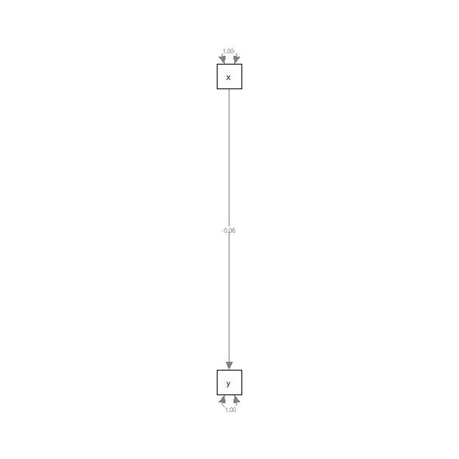

```r
library(semPlot)
semPaths( reg_fit,  whatLabels = "std")
```

`semPaths()` fonksiyonun argümanları ile görseli daha okunabilir hale getirebilirsiniz, bunun yanında layout argümanı ile çıktıyı istediğiniz yerleşim düzeninde verebilirsiniz.

```r
m <- matrix(c("x",NA,NA,"y"), byrow = TRUE, 1, 4)
regresyon_g <- semPaths(reg_fit,
                        whatLabels = "std",
                        sizeMan = 10,  # Gözlenen değişkenlerin boyutu
                        edge.label.cex = 1.15, # Kenar etiketlerinin  boyutu
                        style = "lisrel",
                        layout = m  # düzen
                        )
```

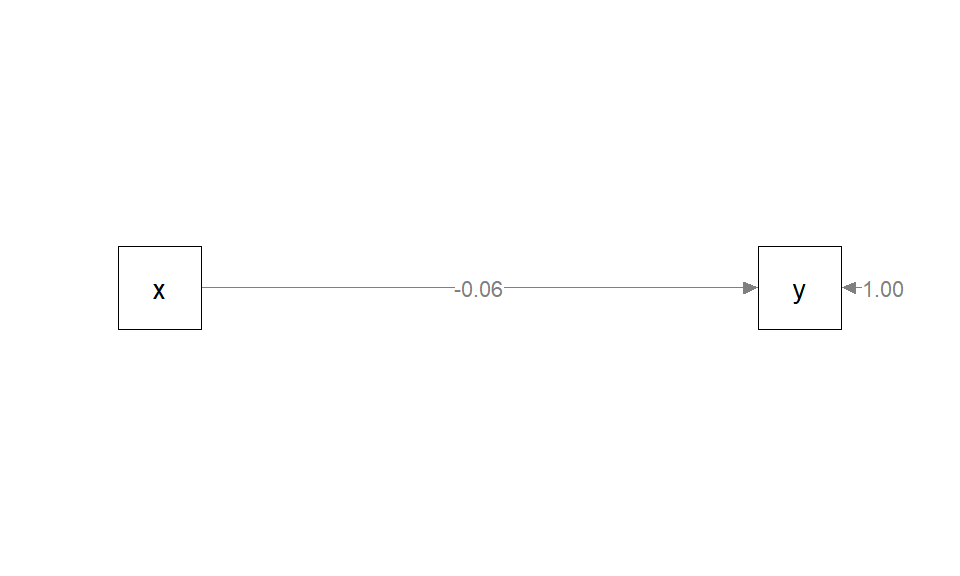

`semPaths()` fonksiyonunun yaygın olarak kullanılan argümanları ve işlevleri hakkında bilgiler aşağıdaki tabloda verilmiştir.

| Argüman | Anlamı | Açıklama |
| --- | --- | --- |
| `object` | Model nesnesi | `lavaan`, `sem`, `MxModel` veya `mplus` nesnesi gibi model nesnesi. |
| `what` | Görselleştirilecek öğe | “paths” (yollar), “est” (tahminler), “std” (standartlaştırılmış tahminler), “model” (model) gibi görselleştirilecek öğeyi belirler. |
| `layout` | Grafik düzeni | “tree”, “circle”, “spring”, “circle2” gibi grafiğin düzenini belirler. |
| `style` | Grafik stili | “ram”, “lisrel” gibi grafik stilini belirler. |
| `title` | Başlık | Grafik başlığını belirler. |
| `sizeMan` | Gözlenen değişken boyutu | Gözlenen değişkenlerin boyutunu belirler. |
| `sizeLat` | Gizil değişken boyutu | Gizil değişkenlerin boyutunu belirler. |
| `residScale` | Hata terimi ölçeği | Hata terimlerinin ölçeğini belirler. |
| `edge.label.cex` | Kenar etiket boyutu | Kenar etiketlerinin (yolların) boyutunu belirler. |
| `node.label.cex` | Düğüm etiket boyutu | Düğüm etiketlerinin (değişkenlerin) boyutunu belirler. |
| `shapeMan` | Gözlenen değişken şekli | Gözlenen değişkenlerin şekli: “rectangle”, “ellipse”, vb. |
| `shapeLat` | Gizil değişken şekli | Gizil değişkenlerin şekli: “ellipse”, “circle”, vb. |
| `node.color` | Düğüm rengi | Düğüm renklerini belirler. |
| `edge.color` | Kenar rengi | Kenar renklerini belirler. |
| `nCharNodes` | Düğüm etiket uzunluğu | Düğüm etiketlerinin kaç karakterle sınırlandırılacağını belirler. |
| `label.scale` | Etiket ölçeklendirme | Etiketlerin otomatik ölçeklendirilip ölçeklendirilmeyeceğini belirler. |
| `fade` | Kenar solukluğu | Kenarların solukluk seviyesini belirler. |
| `residuals` | Hata terimleri | Hata terimlerinin gösterilip gösterilmeyeceğini belirler. |
| `intercepts` | Sabit terimler | Sabit terimlerin gösterilip gösterilmeyeceğini belirler. |
| `thresholds` | Eşik değerleri | Eşik değerlerin gösterilip gösterilmeyeceğini belirler. |
| `fixedStyle` | Sabit parametre stili | Sabit parametrelerin nasıl gösterileceğini belirler. |
| `intStyle` | Etkileşim stili | Etkileşimlerin nasıl gösterileceğini belirler. |
| `nDigits` | Basamak sayısı | Kenar etiketlerinde kaç basamak kullanılacağını belirler. |
| `asize` | Ok ucu boyutu | Okların ucundaki okların boyutunu belirler. |
| `esize` | Kenar boyutu | Kenarların kalınlığını belirler. |
| `combineGroups` | Grupları birleştirme | Grupların birleştirilip birleştirilmeyeceğini belirler. |

semptools paketindeki (Cheung and Lai 2023) `mark_sig()` fonksiyonu ile anlamlı ilişkiler şekil üzerinde aşağıdaki şekilde gösterilebilir. Bunun için `semPaths()` fonsksiyonun çıktısını ve regresyon sonuçlarının çıktısını birer nesneye atamak gereklidir.

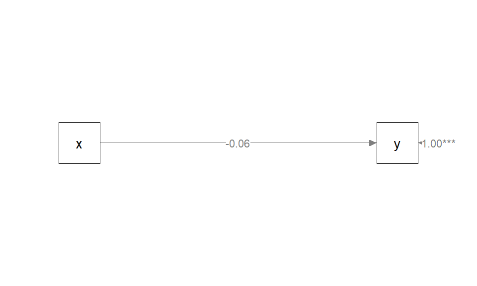

```r
library(semptools)
regresyon_g <- mark_sig(regresyon_g, reg_fit)
plot(regresyon_g)
```

## Model uyumları

semoutput paketindeki (Tsukahara 2024) `sem_tables()` fonksiyonu ile çıktılar tek seferde elde edilebilmektedir.

```r
sem_tables(reg_fit)
```

Model Significance

| N | χ<sup>2</sup> | df | p |
| --- | --- | --- | --- |
| 100 | 0.000 | 0 |  |

Model Fit

| CFI | RMSEA | 90% CI | TLI | SRMR | AIC | BIC |
| --- | --- | --- | --- | --- | --- | --- |
| 1.000 | 0.000 | 0.000 — 0.000 | 1.000 | 0.000 | 272.067 | 277.278 |

Regression Paths

| Predictor | DV | Standardized β | Standardized 95% CI | Standardized sig | Standardized SE | Standardized z | Standardized p |
| --- | --- | --- | --- | --- | --- | --- | --- |
| x | y | −0.060 | −0.255 — 0.136 |  | 0.100 | −0.598 | 0.550 |

* p < .05; ** p < .01; *** p < .001

# Çoklu Regresyon

Çoklu regresyon, basit regresyonun tek bir bağımlı değişkenin iki veya daha fazla yordayıcısına izin veren uzantısıdır. Diğer bir ifadeyle, çoklu regresyon tek bir bağımlı değişken ile iki veya daha fazla bağımsız (yordayıcı) değişken arasındaki ilişkinin analiz edilmesi için kullanılan istatistiksel bir yöntemdir. Çoklu regresyonun amacı değerleri bilinen bağımsız değişkenleri kullanarak bağımlı değişkenin değerini yordamaktır.

## Veri Seti

Kullanılan örnek Guber’in (1999) çalışmasından alınmıştır, bu çalışma aynı zamanda Howell (2013) çoklu regresyon bölümünde de yer almaktadır.

Guber’in (1999), 1997 Eğitim İstatistikleri verilerini kullanarak, eğitim harcamaları ile SAT ile ölçülen akademik performans arasındaki ilişkiyi ele almaktadır. İlk incelemede beklenilenin aksine SAT performansının, yüksek harcama yapan eyaletlerde düşük harcama yapan eyaletlere göre ortalama olarak daha düşük olduğunu göstermektedir. Ancak bu istatistiksel ilişki ihmal edilen bir değişken nedeniyle yanıltıcıdır. Sınava giren öğrencilerin yüzdesi kontrol edildiğinde, harcama ve performans arasındaki ilişki tersine dönerek hem pozitif hem de istatistiksel olarak anlamlı hale gelmektedir.

Şimdi durumu biz inceleyelim.

SAT, ABD’de ağırlıklı olarak ülkenin kuzeydoğu ve batısındaki prestijli üniversite başvurularında kullanılan standart bir testtir.

Aşağıdaki kod ile veri seti SAT nesnesine kaydedilmiştir.

```r
SAT <- readRDS("import/SAT.Rds")
DT::datatable(SAT)
```

|  | id | State | Expend | PTratio | Salary | PctSAT | Verbal | Math | SATcombined | PctACT | ACTcombined | LogPctSAT |
| --- | --- | --- | --- | --- | --- | --- | --- | --- | --- | --- | --- | --- |
| 1 | 1 | Alabama | 4.405 | 17.2 | 31.144 | 8 | 491 | 538 | 1029 | 61 | 20.2 | 2.079 |
| 2 | 2 | Alaska | 8.963 | 17.6 | 47.951 | 47 | 445 | 489 | 934 | 32 | 21 | 3.85 |
| 3 | 3 | Arizona | 4.778 | 19.3 | 32.175 | 27 | 448 | 496 | 944 | 27 | 21.1 | 3.296 |
| 4 | 4 | Ark | 4.459 | 17.1 | 28.934 | 6 | 482 | 523 | 1005 | 66 | 20.3 | 1.792 |
| 5 | 5 | Calif | 4.992 | 24 | 41.078 | 45 | 417 | 485 | 902 | 11 | 21 | 3.807 |
| 6 | 6 | Col | 5.443 | 18.4 | 34.571 | 29 | 462 | 518 | 980 | 62 | 21.5 | 3.367 |
| 7 | 7 | Conn | 8.817 | 14.4 | 50.045 | 81 | 431 | 477 | 908 | 3 | 21.7 | 4.394 |
| 8 | 8 | Del | 7.03 | 16.6 | 39.076 | 68 | 429 | 468 | 897 | 3 | 21 | 4.22 |
| 9 | 9 | Florida | 5.718 | 19.1 | 32.588 | 48 | 420 | 469 | 889 | 36 | 20.7 | 3.871 |
| 10 | 10 | Georgia | 5.193 | 16.3 | 32.291 | 65 | 406 | 448 | 854 | 16 | 20.2 | 4.174 |

[output cut: 40 more lines]

Öncelikle analizlerde kullanılacak değişkenler seçilerek veri seti yeniden isimlendirilmiştir.

```r
# Harcama, Öğretmen-Öğrenci Oranı, Sata girenlerin yüzdesi, birleştirilmiş SAT puanı
SAT <- SAT[c(3,4,6,9)]
names(SAT) <- c("Harcama","Ogret_OgrenciOran","YuzdeSAT","SATpuanı")
head(SAT)
```

```
##   Harcama Ogret_OgrenciOran YuzdeSAT SATpuanı
## 1   4.405              17.2        8     1029
## 2   8.963              17.6       47      934
## 3   4.778              19.3       27      944
## 4   4.459              17.1        6     1005
## 5   4.992              24.0       45      902
## 6   5.443              18.4       29      980
```

Analiz öncesinde, değişkenlerin dağılımları ve birbirleri ile ilişkileri incelenmelidir.

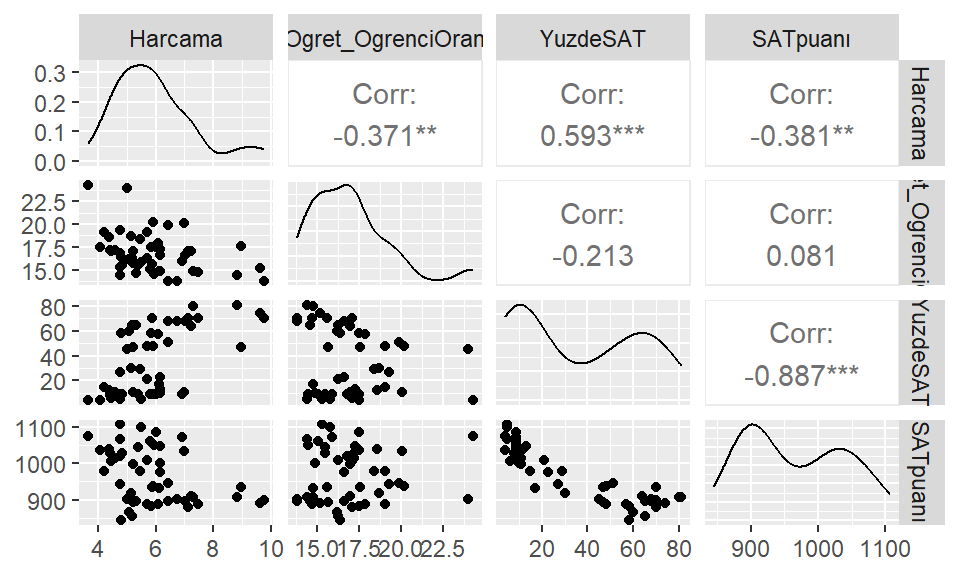

```r
library(GGally)
ggpairs(SAT)
```

Grafiklerden SAT’a girenlerin yüzdesinin 2 modlu olduğu görülmektedir. Bu durum SAT’a giren öğrenci sayısının orta düzeyde olduğu eyalet sayısının oldukça az olduğunu göstermektedir. Bir diğer göstergede SAT’a giren öğrenci sayısı yüzdesi ile SAT puanları arasındaki negatif yönde eğrisel ilişki bulunmasıdır.

Grafikleri biraz daha anlaşılır hale getirmek için aşağıdaki kod kullanılmıştır.

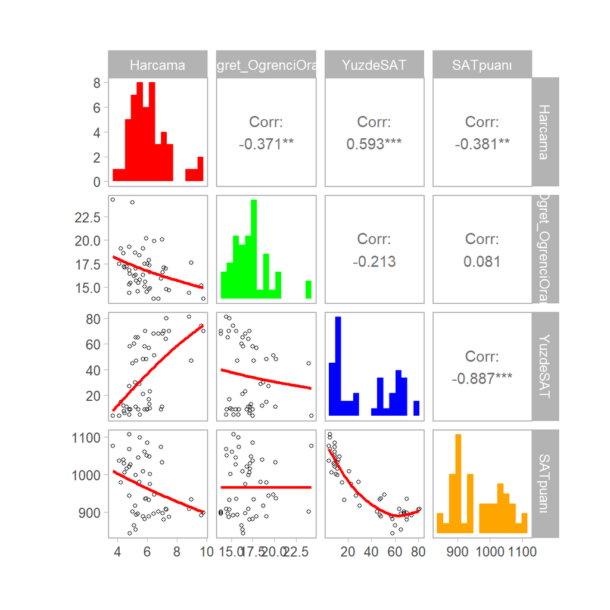

```r
lower_plots <- function(data, mapping, ...) {
    ggplot(data = data, mapping = mapping) +
        geom_point(color = "black", shape = 1, size = 1, alpha = 1) +
        geom_smooth(method = "gam",...)
}

# working with a trick of global assignment
diag_plots <- function(data, mapping, ...) {
    # increase counter each run globally so outside the function as well and this does the trick!
    x <<- x + 1
    ggplot(data = data, mapping = mapping) +
        # choose color by counter and send bin width argument in
        geom_histogram(fill = clrs[x], ...)
}

# set the color and counter
clrs <- c("red","green","blue","orange")
x <- 0

# pairs plot
ggpairs(SAT,1:4,
        diag = list(continuous = wrap(diag_plots, bins = 15)),
        lower = list(continuous = wrap(lower_plots, color="red", se=FALSE))) +
        theme_light(base_size = 12) +
        theme_light(base_size = 12) +
        theme(panel.grid.minor = element_blank(), panel.grid.major = element_blank()) +
    theme(plot.margin = unit(c(2.5,2.5,2.5,3.5), "lines"))
```

SAT’a girenlerin yüzdesi değişkenin doğal logaritması alındığı takdirde bu değişken ile SAT puanları arasındaki ilişki daha doğrusal hale gelmektedir. Regresyon analizine ilişkin örnekte SAT’ ye giren öğrenci yüzdesi yerine bu değişkenin logaritma dönüşümü (logYuzdeSAT) kullanılacaktır. Dönüştürülmüş değişken 2 modlu olsa da söz konusu logaritmik dönüşüm, bu problemin üstesinden gelmeye katkı sağlamaktadır.

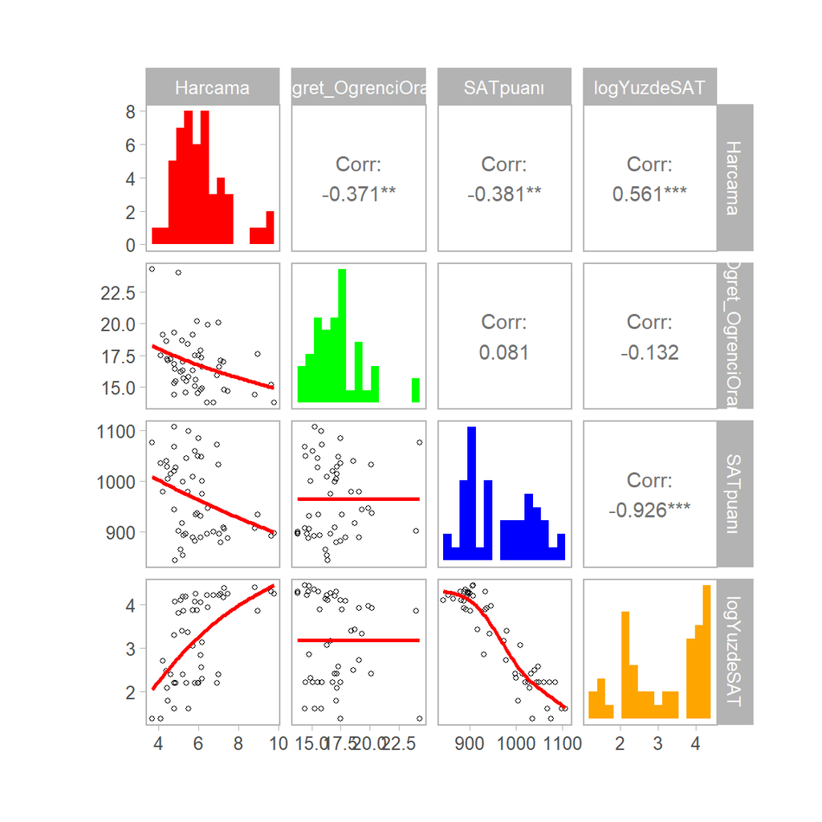

```r
SAT$logYuzdeSAT <- log(SAT$YuzdeSAT)
SAT <- SAT[c(1:2,4:5)]

lower_plots <- function(data, mapping, ...) {
    ggplot(data = data, mapping = mapping) +
        geom_point(color = "black", shape = 1, size = 1, alpha = 1) +
        geom_smooth(method = "gam",...)
}

# working with a trick of global assignment
diag_plots <- function(data, mapping, ...) {
    # increase counter each run globally so outside the function as well and this does the trick!
    x <<- x + 1
    ggplot(data = data, mapping = mapping) +
        # choose color by counter and send bin width argument in
        geom_histogram(fill = clrs[x], ...)
}
clrs <- c("red","green","blue","orange")
x <- 0

ggpairs(SAT,1:4,
        diag = list(continuous = wrap(diag_plots, bins = 15)),
        lower = list(continuous = wrap(lower_plots, color="red", se=FALSE))) +
        theme_light(base_size = 12) +
        theme_light(base_size = 12) +
        theme(panel.grid.minor = element_blank(), panel.grid.major = element_blank()) +
    theme(plot.margin = unit(c(2.5,2.5,2.5,3.5), "lines"))
```

SAT puanları ile eğitim harcamaları arasındaki korelasyon eğrisini negatif olup bu korelasyon, eğitime yapılan harcama arttıkça öğrencilerin başarıları düştüğü anlamına gelmektedir. Bu korelasyon değeri çok yüksek olmasa da manidardır *(r = -0.38, p<0.05)*.

SAT’ye girmek bir zorunluluk değildir ve SATa daha çok prestijli üniversitelere girmek isteyen öğrenciler katılmaktadır.

SAT’ye giren öğrenci sayısı açısından eyaletler arasında büyük farklılıklar bulunmaktadır (%4-%81). Sınava giren öğrenci sayısının düşük olduğu eyaletlerde sadece başarılı olma olasılıkları yüksek olan öğrenciler SATa başvurmaktadır. Öğrencilerin birçoğunun sınava girdiği eyaletlerde ise düşük seviyedeki öğrenciler de SATa başvurmaktadır. Dolayısıyla bu eyaletlerde sınava giren düşük seviyedeki öğrenciler sadece en iyi öğrencilerin sınava girdiği eyaletlere kıyasla bulundukları eyaletin ortalamasını düşürmektedir.

## Regresyon denklemi

SAT puanlarının tek yordayıcısının eğitim harcamaları olduğu model1, SAT puanlarının eğitim harcamaları ve SATa giren bireylerin yüzdesinin logaritması olduğu model2 aşağıda kulrulmuştur

```r
library(lavaan)

# Model tanımı
model_1 <- 'SATpuanı ~ Harcama
               SATpuanı ~ 1'                               # intercept
model_2 <- 'SATpuanı ~ Harcama + logYuzdeSAT
               SATpuanı ~ 1'                               # intercept

# Modeli fit etme
fit_1 <- sem(model_1, data = SAT)
fit_2 <- sem(model_2, data = SAT)
```

```r
sem_paths(fit_1)
```

Regression Paths

| Predictor | DV | Standardized β | Standardized 95% CI | Standardized sig | Standardized SE | Standardized z | Standardized p |
| --- | --- | --- | --- | --- | --- | --- | --- |
| Harcama | SATpuanı | −0.381 | −0.609 — −0.152 | ** | 0.116 | −3.267 | 0.001 |

* p < .05; ** p < .01; *** p < .001

```r
summary(fit_1, rsquare=TRUE,standardized =TRUE)
```

```
## lavaan 0.6.17 ended normally after 1 iteration
##
##   Estimator                                         ML
##   Optimization method                           NLMINB
##   Number of model parameters                         3
##
##   Number of observations                            50
##
## Model Test User Model:
##
##   Test statistic                                 0.000
##   Degrees of freedom                                 0
##
## Parameter Estimates:
##
##   Standard errors                             Standard
##   Information                                 Expected
##   Information saturated (h1) model          Structured
##
## Regressions:
##                    Estimate  Std.Err  z-value  P(>|z|)   Std.lv  Std.all
##   SATpuanı ~
##     Harcama         -20.892    7.180   -2.910    0.004  -20.892   -0.381
##
## Intercepts:
##                   Estimate  Std.Err  z-value  P(>|z|)   Std.lv  Std.all
##    .SATpuanı      1089.294   43.493   25.045    0.000 1089.294   14.707
##
## Variances:
##                   Estimate  Std.Err  z-value  P(>|z|)   Std.lv  Std.all
##    .SATpuanı      4691.712  938.342    5.000    0.000 4691.712    0.855
##
## R-Square:
##                   Estimate
##     SATpuanı         0.145
```

model_1 sonuçları incelendiğinde sat puanlarındaki varyansının %14.5’lik kısmının eğitim harcamaları ile açıklandığı görülmektedir. (−0.381^2 =14.5)

model2 sonuçlarına göz atalım

```r
sem_paths(fit_2)
```

Regression Paths

| Predictor | DV | Standardized β | Standardized 95% CI | Standardized sig | Standardized SE | Standardized z | Standardized p |
| --- | --- | --- | --- | --- | --- | --- | --- |
| Harcama | SATpuanı | 0.203 | 0.091 — 0.314 | *** | 0.057 | 3.570 | <0.001 |
| logYuzdeSAT | SATpuanı | −1.040 | −1.093 — −0.987 | *** | 0.027 | −38.775 | 0.000 |

* p < .05; ** p < .01; *** p < .001

```r
summary(fit_2, rsquare=TRUE,standardized =TRUE)
```

```
## lavaan 0.6.17 ended normally after 1 iteration
##
##   Estimator                                         ML
##   Optimization method                           NLMINB
##   Number of model parameters                         4
##
##   Number of observations                            50
##
## Model Test User Model:
##
##   Test statistic                                 0.000
##   Degrees of freedom                                 0
##
## Parameter Estimates:
##
##   Standard errors                             Standard
##   Information                                 Expected
##   Information saturated (h1) model          Structured
##
## Regressions:
##                    Estimate  Std.Err  z-value  P(>|z|)   Std.lv  Std.all
##   SATpuanı ~
##     Harcama          11.130    3.165    3.517    0.000   11.130    0.203
##     logYuzdeSAT     -78.205    4.335  -18.041    0.000  -78.205   -1.040
##
## Intercepts:
##                   Estimate  Std.Err  z-value  P(>|z|)   Std.lv  Std.all
##    .SATpuanı      1147.113   16.192   70.846    0.000 1147.113   15.487
##
## Variances:
##                   Estimate  Std.Err  z-value  P(>|z|)   Std.lv  Std.all
##    .SATpuanı       624.768  124.954    5.000    0.000  624.768    0.114
##
## R-Square:
##                   Estimate
##     SATpuanı         0.886
```

Model 2’de sınava girenlerin yüzdesi değişkeni analize alındığında ise SAT puanlarındaki varyansının %88.6’sının eğitim harcamaları ve sınava girenlerin yüzdesi değişkenleri ile açıklandığı görülmektedir.

Ayrıca SAT’ye giren öğrenci yüzdesi değişkeni açıklanan varyansı %14.5’ten %88.6’ya çıkarmıştır.

Sınava giren öğrencilerin yüzdesi kontrol edildiğinde, eğitime yapılan harcama ile SAT puanlarının ilişkisi pozitif hale gelir ve istatistiksel olarak anlamlı olur. Bu durum, sınava giren öğrenci yüzdesinin, iki değişken arasındaki gerçek ilişkiyi baskılayarak gizlediğini ve kontrol edilmediğinde ilişkinin zayıf veya ters görünmesine neden olduğunu gösterir. Dolayısıyla, sınava giren öğrenci yüzdesi, bu iki değişken arasındaki ilişkiyi daha doğru bir şekilde ortaya çıkaran bastırıcı bir değişken örneğidir.

Regresyon çıktılarını daha düzgün almanın bir yolu da `stargazer` paketinin aynı isimli fonkisyonunu kullanmaktır. Ancak bu paket kullanılmak istendiğinde modeller lavaan paketi ile değil, `lm()` fonksiyonu ile kullanılmalıdır.

```r
library(stargazer)
fita <- lm(SATpuanı ~ Harcama,  data=SAT)
fitb <- lm(SATpuanı ~ Harcama + logYuzdeSAT, data=SAT)

# Özet tablo
stargazer(fita, fitb, type = "text", title = "Özet tablo")
```

```
##
## Özet tablo
## =================================================================
##                                  Dependent variable:
##                     ---------------------------------------------
##                                       SATpuanı
##                              (1)                    (2)
## -----------------------------------------------------------------
## Harcama                  -20.892***              11.130***
##                            (7.328)                (3.264)
##
## logYuzdeSAT                                     -78.205***
##                                                   (4.471)
##
## Constant                1,089.294***           1,147.113***
##                           (44.390)               (16.700)
##
## -----------------------------------------------------------------
## Observations                 50                     50
## R2                          0.145                  0.886
## Adjusted R2                 0.127                  0.881
## Residual Std. Error   69.909 (df = 48)       25.781 (df = 47)
## F Statistic         8.128*** (df = 1; 48) 182.856*** (df = 2; 47)
## =================================================================
## Note:                                 *p<0.1; **p<0.05; ***p<0.01
```

Regresyon, yol analizi ve yapısal eşitlik modellerinde kurulan modele göre aynı değişkenin katsayısı çok farklı olabilmektedir. Bu analizlerde bastırıcı (suppressor), bozucu (confounding), aracı (mediator) ve düzenleyici(moderator) değişkenlerin rolü ve önemine dikkat etmek gerekmektedir.

# Faktör Analizi

*Bu bölüm zaman kısıtı nedeniyle anlatılmayacaktır. Kodları inceleyebilmeniz için bırakılmıştır.*

lavaan, gözlemlenen değişkenlerin altında yatan faktörleri belirlemek için faktör analizi yapma imkanı sunar. Faktör analizinde SPSS Anksiyete Anketi’nin (SAQ) ilk sekiz maddesine 2571 kişinin verdiği cevapları kullanacağız.

1. Statistics makes me cry
2. My friends will think I’m stupid for not being able to cope with SPSS
3. Standard deviations excite me
4. I dream that Pearson is attacking me with correlation coefficients
5. I don’t understand statistics
6. I have little experience with computers
7. All computers hate me
8. I have never been good at mathematics

Veri setini R ortamına aktarıp, ilk 8 maddedeki korelasyonları inceleyelim.

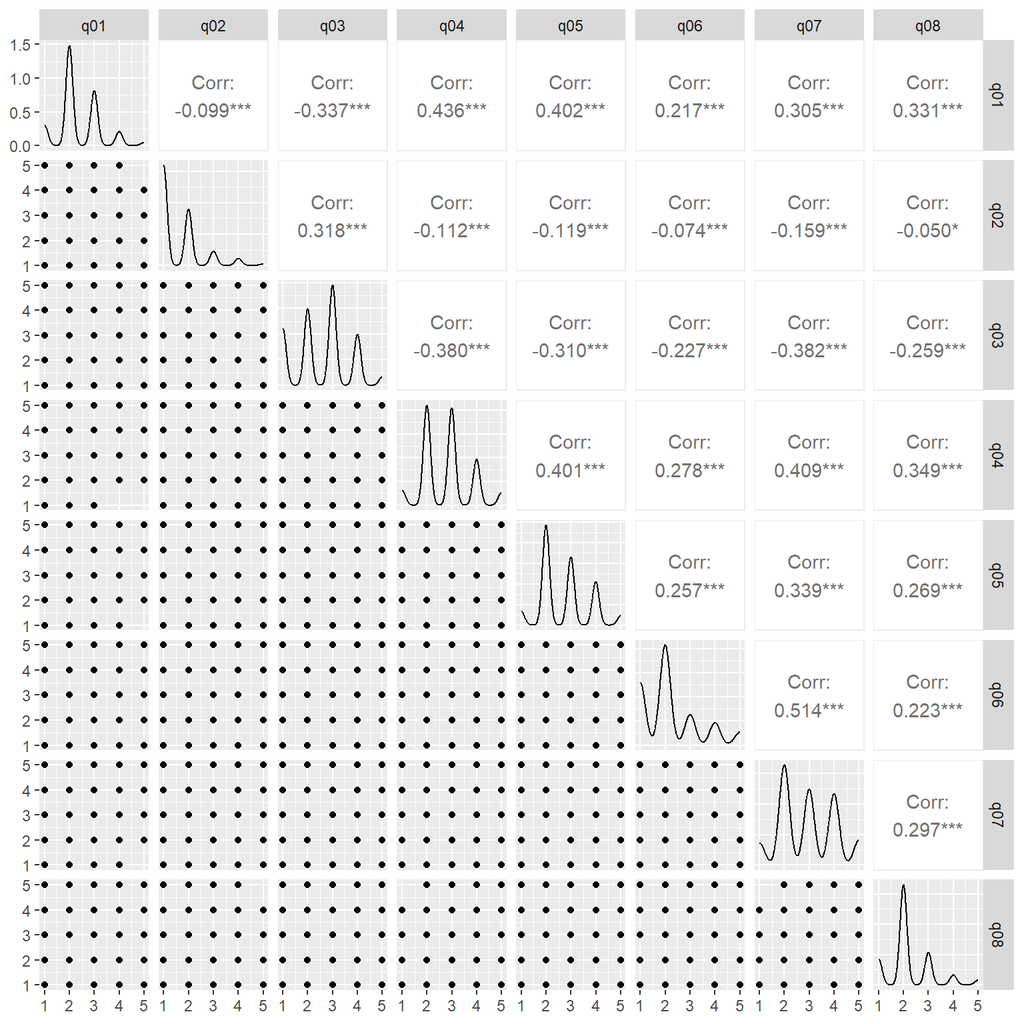

```r
library(GGally)
# Veri seti
fa_data  <- readRDS("import/SAQ.Rds")
ggpairs(fa_data[,1:8])
```

## İki faktörlü model

q2 maddesi diğer maddeler ile düşük düzeyde korelasyonlar verdiği için modele alınmamıştır. Bu durumda 7 madde ile 2 faktörlü model kurulması örneği aşağıda verilmiştir.

```r
fa_model <- 'f1 =~ q01 + q03 + q04 + q05 + q08
             f2 =~ q06 + q07'
```

Faktör analizinde gizil değişkenin ölçeğini 1’e ve ortalamasını 0’a ayarlamak, gizil değişkene ölçek atamanın bir yoludur. Bu, aslında, gizil değişkeni standartlaştırılmış bir değişken haline getirir (yani, Z ölçeğinde). Gizil değişkene ölçek atamanın diğer bir yolu her gizil değişken için tek bir faktör yükünü keyfi bir değere sabitlemektir (genellikle 1’e sabitlenir). Bu, gizil değişken ile gözlenen değişkenin aynı ölçüm düzeyinde olmasını sağlar. Yükü kısıtlanan değişken bir işaretleyici değişkendir. lavaan paketinin varsayılan olarak yaptığı da budur.

Gözlenen değişken sayısı 7 olduğu için varyans-covayans matirisinin eleman sayısı (7*(7+1))/2 = 28’dir.

Modelin analizi sonucu kestirilecek parametreler ise

- 5 madde için faktör yükü ( her iki faktör içinde ilk gösterge yükü 1’ e eşitlenir.)
- 7 madde için hata varyansı
- 1 faktörler arası kovaryans
- 2 faktörler varyansı

kestirelecek parametre sayısı 5 + 7 + 1 + 2 = 15

sd = 28 -15 = 13

- sd<0 olduğunda model tanımlanamaz.
- sd=0, model ancak tanımlanır (just identification) ve kuramsal olarak her parametrenin tek bir çözümü vardır. Ancak tanımlanan modellerde model veriye mükemmel uyum gösterir.
- sd>0, model aşırı tanımlanmış (over identification) olur. Aşırı tanımlanan modellerde kuramsal olarak her bir parametrenin birden fazla çözümü vardır.

NOT: Tek faktörlü modellerde bir faktörün üç göstergesi olduğunda o model sd=0 olacağı için ancak tanımlanmış model olacaktır.

Tek faktörlü modellerde bir faktörün iki göstergesi olduğunda o model sd=-1 olacağı için tanımlanmaz. Göstergelerin yükleri birbirine eşit olarak ayarlanırsa sd=0 olacaktır.

```r
# Modeli fit etme
fa_fit <- sem(fa_model, data = fa_data)
summary(fa_fit,fit.measures=TRUE,standardized=TRUE)
```

```
## lavaan 0.6.17 ended normally after 29 iterations
##
##   Estimator                                         ML
##   Optimization method                           NLMINB
##   Number of model parameters                        15
##
##   Number of observations                          2571
##
## Model Test User Model:
##
##   Test statistic                                66.768
##   Degrees of freedom                                13
##   P-value (Chi-square)                           0.000
##
## Model Test Baseline Model:
##
##   Test statistic                              3876.345
##   Degrees of freedom                                21
##   P-value                                        0.000
##
## User Model versus Baseline Model:
##
##   Comparative Fit Index (CFI)                    0.986
##   Tucker-Lewis Index (TLI)                       0.977
##
## Loglikelihood and Information Criteria:
##
##   Loglikelihood user model (H0)             -23296.945
##   Loglikelihood unrestricted model (H1)     -23263.562
##
##   Akaike (AIC)                               46623.891
##   Bayesian (BIC)                             46711.672
##   Sample-size adjusted Bayesian (SABIC)      46664.013
##
## Root Mean Square Error of Approximation:
##
##   RMSEA                                          0.040
##   90 Percent confidence interval - lower         0.031
##   90 Percent confidence interval - upper         0.050
##   P-value H_0: RMSEA <= 0.050                    0.952
```

[output cut: 25 more lines]

```
##                    Estimate  Std.Err  z-value  P(>|z|)   Std.lv  Std.all
##   f1 ~~
##     f2                0.232    0.015   15.175    0.000    0.676    0.676
##
## Variances:
##                    Estimate  Std.Err  z-value  P(>|z|)   Std.lv  Std.all
##    .q01               0.423    0.014   29.157    0.000    0.423    0.617
##    .q03               0.796    0.026   31.025    0.000    0.796    0.689
##    .q04               0.466    0.018   25.824    0.000    0.466    0.518
##    .q05               0.608    0.020   30.173    0.000    0.608    0.654
##    .q08               0.572    0.018   32.332    0.000    0.572    0.752
##    .q06               0.811    0.030   27.187    0.000    0.811    0.644
##    .q07               0.314    0.040    7.815    0.000    0.314    0.258
##     f1                0.263    0.017   15.230    0.000    1.000    1.000
##     f2                0.447    0.033   13.500    0.000    1.000    1.000
```

```r
# Model tanımı
fa_model1 <- 'f1 =~ NA*q01 + q03 + q04 + q05 + q08
              f2 =~ NA*q06 + q07
              f1 ~~ 1*f1
              f2 ~~ 1*f2
'

# Modeli fit etme
fa_fit1<- sem(fa_model1, data = fa_data)
summary(fa_fit1,fit.measures=TRUE,standardized=TRUE)
```

```
## lavaan 0.6.17 ended normally after 18 iterations
##
##   Estimator                                         ML
##   Optimization method                           NLMINB
##   Number of model parameters                        15
##
##   Number of observations                          2571
##
## Model Test User Model:
##
##   Test statistic                                66.768
##   Degrees of freedom                                13
##   P-value (Chi-square)                           0.000
##
## Model Test Baseline Model:
##
##   Test statistic                              3876.345
##   Degrees of freedom                                21
##   P-value                                        0.000
##
## User Model versus Baseline Model:
##
##   Comparative Fit Index (CFI)                    0.986
##   Tucker-Lewis Index (TLI)                       0.977
##
## Loglikelihood and Information Criteria:
##
##   Loglikelihood user model (H0)             -23296.945
##   Loglikelihood unrestricted model (H1)     -23263.562
##
##   Akaike (AIC)                               46623.891
##   Bayesian (BIC)                             46711.672
##   Sample-size adjusted Bayesian (SABIC)      46664.013
##
## Root Mean Square Error of Approximation:
##
##   RMSEA                                          0.040
##   90 Percent confidence interval - lower         0.031
##   90 Percent confidence interval - upper         0.050
##   P-value H_0: RMSEA <= 0.050                    0.952
```

[output cut: 25 more lines]

```
##                    Estimate  Std.Err  z-value  P(>|z|)   Std.lv  Std.all
##   f1 ~~
##     f2                0.676    0.020   33.023    0.000    0.676    0.676
##
## Variances:
##                    Estimate  Std.Err  z-value  P(>|z|)   Std.lv  Std.all
##     f1                1.000                               1.000    1.000
##     f2                1.000                               1.000    1.000
##    .q01               0.423    0.014   29.157    0.000    0.423    0.617
##    .q03               0.796    0.026   31.025    0.000    0.796    0.689
##    .q04               0.466    0.018   25.824    0.000    0.466    0.518
##    .q05               0.608    0.020   30.173    0.000    0.608    0.654
##    .q08               0.572    0.018   32.332    0.000    0.572    0.752
##    .q06               0.811    0.030   27.187    0.000    0.811    0.644
##    .q07               0.314    0.040    7.815    0.000    0.314    0.258
```

### Görselleştirme

```r
fa_ikif <- semPaths( fa_fit,  whatLabels = "std",
                  style="lisrel",layout="tree",residuals = TRUE,rotation = 2,
                    sizeMan = 10,   edge.label.cex = 1.15, nCharNodes = 0)
```

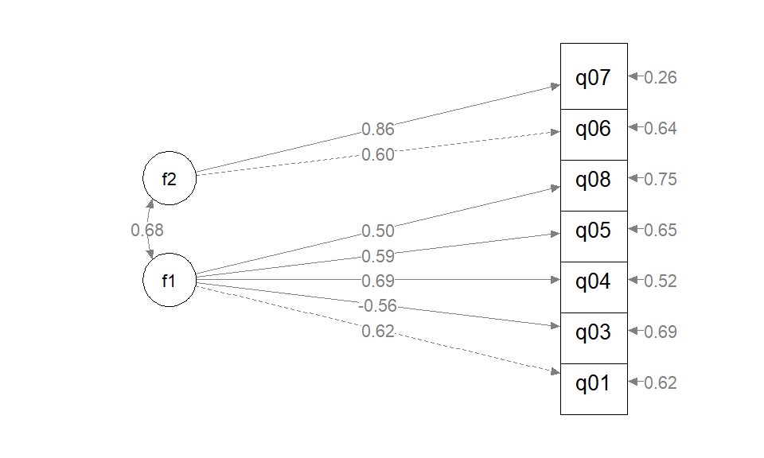

Anlamlı katsayların işaretlenmesi

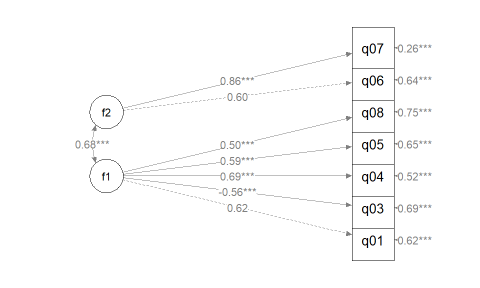

```r
fa_ikif_g <- mark_sig(fa_ikif, fa_fit)
plot(fa_ikif_g)
```

Tablo halinde tüm sonuçların sunulması

```r
sem_tables(fa_fit)
```

Model Significance

| N | χ<sup>2</sup> | df | p |
| --- | --- | --- | --- |
| 2571 | 66.768 | 13 | <0.001 |

Model Fit

| CFI | RMSEA | 90% CI | TLI | SRMR | AIC | BIC |
| --- | --- | --- | --- | --- | --- | --- |
| 0.986 | 0.040 | 0.031 — 0.050 | 0.977 | 0.021 | 46623.891 | 46711.672 |

Factor Loadings

| Latent Factor | Indicator | Standardized Loading | Standardized 95% CI | Standardized sig | Standardized SE | Standardized z | Standardized p |
| --- | --- | --- | --- | --- | --- | --- | --- |
| f1 | q01 | 0.619 | 0.588 — 0.650 | *** | 0.016 | 39.421 | 0.000 |
| f1 | q03 | −0.557 | −0.591 — −0.524 | *** | 0.017 | −33.055 | 0.000 |
| f1 | q04 | 0.694 | 0.666 — 0.722 | *** | 0.014 | 48.449 | 0.000 |
| f1 | q05 | 0.588 | 0.556 — 0.620 | *** | 0.016 | 36.103 | 0.000 |
| f1 | q08 | 0.498 | 0.463 — 0.534 | *** | 0.018 | 27.806 | 0.000 |
| f2 | q06 | 0.596 | 0.561 — 0.632 | *** | 0.018 | 32.852 | 0.000 |
| f2 | q07 | 0.861 | 0.823 — 0.899 | *** | 0.019 | 44.403 | 0.000 |

* p < .05; ** p < .01; *** p < .001

Latent Factor Correlations

| Factor | Factor | r | 95% CI | sig | SE | p |
| --- | --- | --- | --- | --- | --- | --- |
| f1 | f2 | 0.676 | 0.636 — 0.716 | *** | 0.020 | 0.000 |

* p < .05; ** p < .01; *** p < .001

Latent Factor Variance/Residual Variance

| Factor | Variance | Std. Variance | sig | p |
| --- | --- | --- | --- | --- |
| f1 | 0.263 | 1.000 | *** | 0.000 |
| f2 | 0.447 | 1.000 | *** | 0.000 |

## İki düzeyli model

Gizil değişken F, gizil olduğundan sabit bir ölçeğe sahip değildir. Bu nedenle, faktör yüklerinin ölçekleri belirlenemez. İki olası çözüm aşağıdaki gibidir:

- Faktör yüklerin ölçeği sabitlenir ve gizil değişkenin ölçeği serbestçe kestirilir (faktördeki ilk madde yükünü 1’e sabitlenmesi)
- Gizil değişkenin ölçeği sabitlenir ve faktör yüklerinin ölçekleri serbestçe kestirilir (her bir faktörün varyansını 1’e sabitlenir.
- Yalnızca iki birinci dereceden faktörünüz olduğunda ikinci dereceden bir faktör belirlemenin mükemmel bir yolu olmadığını unutmayın. Ya ikinci dereceden faktörün varyansının 1 olduğunu varsaymanız ya da her bir maddenin faktör yükünü 1’e eşit olarak ayarlayıp varyansı tahmin etmeniz gerekir.

```r
# İkinci dereceden üç faktörlü çözüm, marker yöntemi
fa_model_so  <- 'f1 =~ q01+ q03 + q04 + q05 + q08
        f2 =~ q06 + q07
        f3 =~ 1*f1 + 1*f2
        f3 ~~ f3'
secondorder <- cfa(fa_model_so, data=fa_data)
summary(secondorder,fit.measures=TRUE,        standardized=TRUE)
```

```
## lavaan 0.6.17 ended normally after 30 iterations
##
##   Estimator                                         ML
##   Optimization method                           NLMINB
##   Number of model parameters                        15
##
##   Number of observations                          2571
##
## Model Test User Model:
##
##   Test statistic                                66.768
##   Degrees of freedom                                13
##   P-value (Chi-square)                           0.000
##
## Model Test Baseline Model:
##
##   Test statistic                              3876.345
##   Degrees of freedom                                21
##   P-value                                        0.000
##
## User Model versus Baseline Model:
##
##   Comparative Fit Index (CFI)                    0.986
##   Tucker-Lewis Index (TLI)                       0.977
##
## Loglikelihood and Information Criteria:
##
##   Loglikelihood user model (H0)             -23296.945
##   Loglikelihood unrestricted model (H1)     -23263.562
##
##   Akaike (AIC)                               46623.891
##   Bayesian (BIC)                             46711.672
##   Sample-size adjusted Bayesian (SABIC)      46664.013
##
## Root Mean Square Error of Approximation:
##
##   RMSEA                                          0.040
##   90 Percent confidence interval - lower         0.031
##   90 Percent confidence interval - upper         0.050
##   P-value H_0: RMSEA <= 0.050                    0.952
```

[output cut: 24 more lines]

```
##     f1                1.000                               0.939    0.939
##     f2                1.000                               0.720    0.720
##
## Variances:
##                    Estimate  Std.Err  z-value  P(>|z|)   Std.lv  Std.all
##     f3                0.232    0.015   15.175    0.000    1.000    1.000
##    .q01               0.423    0.014   29.157    0.000    0.423    0.617
##    .q03               0.796    0.026   31.025    0.000    0.796    0.689
##    .q04               0.466    0.018   25.824    0.000    0.466    0.518
##    .q05               0.608    0.020   30.173    0.000    0.608    0.654
##    .q08               0.572    0.018   32.332    0.000    0.572    0.752
##    .q06               0.811    0.030   27.187    0.000    0.811    0.644
##    .q07               0.314    0.040    7.815    0.000    0.314    0.258
##    .f1                0.031    0.015    2.057    0.040    0.118    0.118
##    .f2                0.216    0.024    8.867    0.000    0.482    0.482
```

```r
fa_g <- semPaths( secondorder,  whatLabels = "std",
                  style="lisrel",layout="tree",residuals = TRUE,rotation = 2,
                    sizeMan = 10,   edge.label.cex = 1.15, nCharNodes = 0)
```

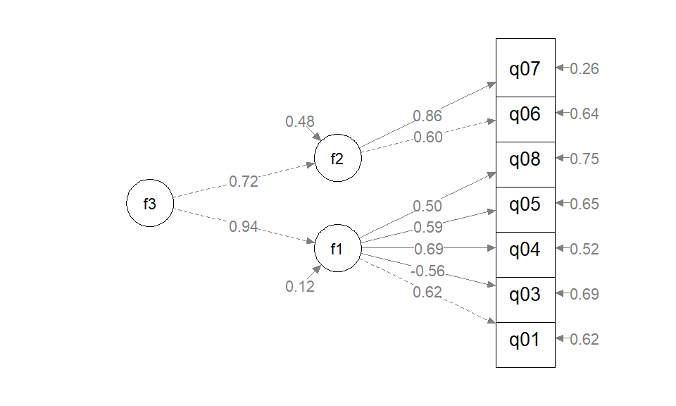

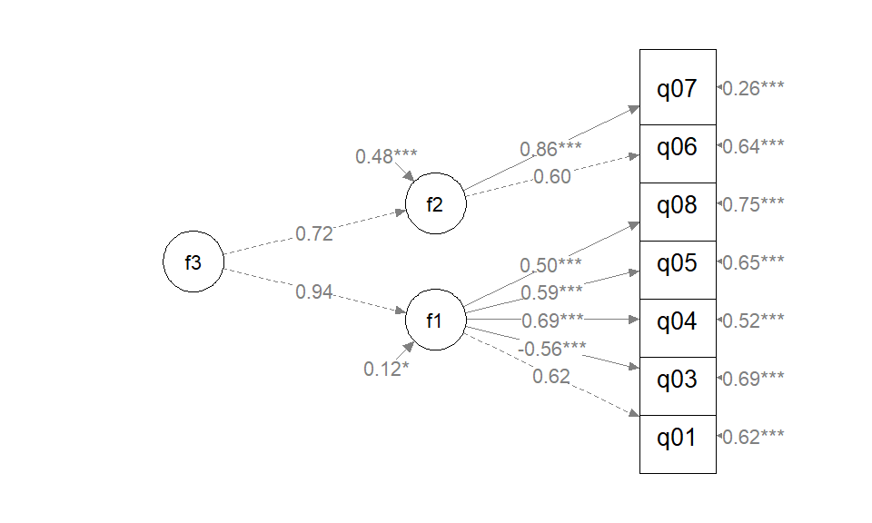

```r
secondorder_g <- mark_sig(fa_g, secondorder)
plot(secondorder_g)
```

**İki düzeyli model _ v1**

Aşağıdaki kodda NA * f1 ve NA * q06 ilk maddelerin yüklerinin serbest kestirilmesi anlamına gelir çünkü varsayılan olarak maddelerin yüklerinin 1 olmasıdır ve equal(“f3=~f1”)*f2 ikinci faktörün üçüncü faktör üzerindeki yüklemesini birinci faktörle aynı olacak şekilde sabitlemsidir

```r
# İkinci dereceden üç faktörlü çözüm var std method
fa_model_so_v1 <- 'f1 =~ NA*q01+ q03 + q04 + q05 + q08
        f2 =~ NA*q06 + q07
        f3 =~ NA*f1 + equal("f3=~f1")*f2
        f1 ~~ 1*f1
        f2 ~~ 1*f2
        f3 ~~ 1*f3'
secondorder_v1 <- sem(fa_model_so_v1, data=fa_data)
summary(secondorder_v1,fit.measures=TRUE,standardized=TRUE)
```

```
## lavaan 0.6.17 ended normally after 27 iterations
##
##   Estimator                                         ML
##   Optimization method                           NLMINB
##   Number of model parameters                        16
##   Number of equality constraints                     1
##
##   Number of observations                          2571
##
## Model Test User Model:
##
##   Test statistic                                66.768
##   Degrees of freedom                                13
##   P-value (Chi-square)                           0.000
##
## Model Test Baseline Model:
##
##   Test statistic                              3876.345
##   Degrees of freedom                                21
##   P-value                                        0.000
##
## User Model versus Baseline Model:
##
##   Comparative Fit Index (CFI)                    0.986
##   Tucker-Lewis Index (TLI)                       0.977
##
## Loglikelihood and Information Criteria:
##
##   Loglikelihood user model (H0)             -23296.945
##   Loglikelihood unrestricted model (H1)     -23263.562
##
##   Akaike (AIC)                               46623.891
##   Bayesian (BIC)                             46711.672
##   Sample-size adjusted Bayesian (SABIC)      46664.013
##
## Root Mean Square Error of Approximation:
##
##   RMSEA                                          0.040
##   90 Percent confidence interval - lower         0.031
##   90 Percent confidence interval - upper         0.050
```

[output cut: 25 more lines]

```
##     f1      (.p8.)    1.443    0.067   21.420    0.000    0.822    0.822
##     f2      (f3=~)    1.443    0.067   21.420    0.000    0.822    0.822
##
## Variances:
##                    Estimate  Std.Err  z-value  P(>|z|)   Std.lv  Std.all
##    .f1                1.000                               0.324    0.324
##    .f2                1.000                               0.324    0.324
##     f3                1.000                               1.000    1.000
##    .q01               0.423    0.014   29.157    0.000    0.423    0.617
##    .q03               0.796    0.026   31.025    0.000    0.796    0.689
##    .q04               0.466    0.018   25.824    0.000    0.466    0.518
##    .q05               0.608    0.020   30.173    0.000    0.608    0.654
##    .q08               0.572    0.018   32.332    0.000    0.572    0.752
##    .q06               0.811    0.030   27.187    0.000    0.811    0.644
##    .q07               0.314    0.040    7.815    0.000    0.314    0.258
```

### Görselleştirme

```r
fa_g_v1 <- semPaths( secondorder_v1,  whatLabels = "std",
                  style="lisrel",layout="tree",residuals = TRUE,rotation = 2,
                    sizeMan = 10,   edge.label.cex = 1.15, nCharNodes = 0)
```

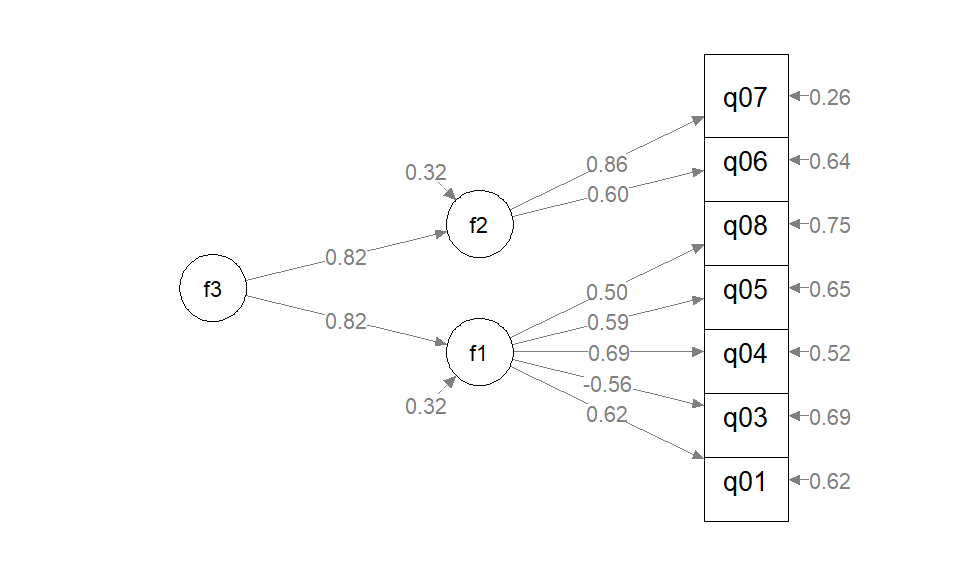

Anlamlı katsayların işaretlenmesi

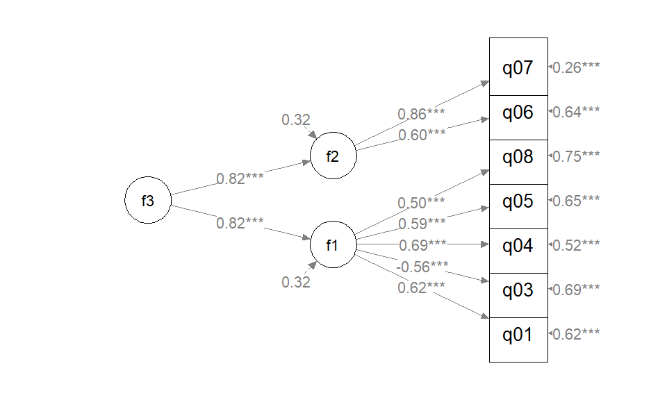

```r
secondorder_g_v1 <- mark_sig(fa_g_v1, secondorder_v1)
plot(secondorder_g_v1)
```

Tablo halinde tüm sonuçların sunulması

```r
sem_tables(secondorder_v1)
```

Model Significance

| N | χ<sup>2</sup> | df | p |
| --- | --- | --- | --- |
| 2571 | 66.768 | 13 | <0.001 |

Model Fit

| CFI | RMSEA | 90% CI | TLI | SRMR | AIC | BIC |
| --- | --- | --- | --- | --- | --- | --- |
| 0.986 | 0.040 | 0.031 — 0.050 | 0.977 | 0.021 | 46623.891 | 46711.672 |

Factor Loadings

| Latent Factor | Indicator | Standardized Loading | Standardized 95% CI | Standardized sig | Standardized SE | Standardized z | Standardized p |
| --- | --- | --- | --- | --- | --- | --- | --- |
| f1 | q01 | 0.619 | 0.588 — 0.650 | *** | 0.016 | 39.420 | 0.000 |
| f1 | q03 | −0.557 | −0.591 — −0.524 | *** | 0.017 | −33.055 | 0.000 |
| f1 | q04 | 0.694 | 0.666 — 0.722 | *** | 0.014 | 48.449 | 0.000 |
| f1 | q05 | 0.588 | 0.556 — 0.620 | *** | 0.016 | 36.103 | 0.000 |
| f1 | q08 | 0.498 | 0.463 — 0.534 | *** | 0.018 | 27.806 | 0.000 |
| f2 | q06 | 0.596 | 0.561 — 0.632 | *** | 0.018 | 32.852 | 0.000 |
| f2 | q07 | 0.861 | 0.823 — 0.899 | *** | 0.019 | 44.403 | 0.000 |
| f3 | f1 | 0.822 | 0.798 — 0.846 | *** | 0.012 | 66.046 | 0.000 |
| f3 | f2 | 0.822 | 0.798 — 0.846 | *** | 0.012 | 66.046 | 0.000 |

* p < .05; ** p < .01; *** p < .001

Explained Variance

| Variable | R<sup>2</sup> |
| --- | --- |
| f1 | 0.676 |
| f2 | 0.676 |

## Kaynaklar

Howell, D. C. (2013). Statistical Methods for Psychology (8th ed.). Wadsworth.

Lynn Guber, D. (1999). Getting what you pay for: The debate over equity in public school expenditures. Journal of Statistics Education, 7(2).

Cheung, Shu Fai, and Mark Hok Chio Lai. 2023. “Semptools: Customizing Structural Equation Modelling Plots.” https://CRAN.R-project.org/package=semptools.

Epskamp, Sacha. 2022. “semPlot: Path Diagrams and Visual Analysis of Various SEM Packages’ Output.” https://CRAN.R-project.org/package=semPlot.

Robinson, David, Alex Hayes, and Simon Couch. 2023. “Broom: Convert Statistical Objects into Tidy Tibbles.” https://CRAN.R-project.org/package=broom.

Rosseel, Yves. 2012. “Lavaan: An r Package for Structural Equation Modeling” 48. https://doi.org/10.18637/jss.v048.i02.

Schloerke, Barret, Di Cook, Joseph Larmarange, Francois Briatte, Moritz Marbach, Edwin Thoen, Amos Elberg, and Jason Crowley. 2024. “GGally: Extension to ’Ggplot2’.” https://CRAN.R-project.org/package=GGally.

Tsukahara, Jason. 2024. “Semoutput: SEM Output.” https://github.com/dr-JT/semoutput.

Xie, Yihui. 2024. “Knitr: A General-Purpose Package for Dynamic Report Generation in r.” https://yihui.org/knitr/.